# Session 2 — Kaplan-Meier Curves

Estimating survival · medians and landmarks · confidence bands · groups and risk tables · Lab 2

Community Medicine Workshop

## Where we are

- Session 1: censoring, the Surv object, rates
- Today: **estimate and draw the survival curve** without assuming a constant rate
- By the end you can:
  - fit and read a **Kaplan-Meier** curve
  - report **survival at a time point** and the **median** (or “not reached”)
  - draw curves by group with a **number-at-risk table**

# Topic 1 — How the estimate is built

## A step function

At each **event time**, survival drops by the fraction who die among those **still at risk**; **censored** patients leave the risk set without causing a drop.

S(t) = Π (1 − d<sub>i</sub> / n<sub>i</sub>) over event times ≤ t

```r
toy <- tibble(time = c(2, 3, 3, 5, 7, 8), status = c(1, 1, 0, 1, 0, 1))
summary(survfit(Surv(time, status) ~ 1, toy))
```

```
Call: survfit(formula = Surv(time, status) ~ 1, data = toy)

 time n.risk n.event survival std.err lower 95% CI upper 95% CI
    2      6       1    0.833   0.152        0.583            1
    3      5       1    0.667   0.192        0.379            1
    5      3       1    0.444   0.222        0.167            1
    8      1       1    0.000     NaN           NA           NA
```

## Reading the toy example

- At time 2: 6 at risk, 1 dies: 1 × 5/6 = 0.83
- At time 3: 5 at risk, 1 dies and 1 is censored: 0.83 × 4/5 = 0.67
- The censored patient **counts in the denominator until censored**, then leaves

## The overall curve

```r
km <- survfit(Surv(time_months, status) ~ 1, data = tb)
km
```

```
Call: survfit(formula = Surv(time_months, status) ~ 1, data = tb)

       n events median 0.95LCL 0.95UCL
[1,] 600    113     NA      NA      NA
```

```r
ggsurvfit(km) + add_confidence_interval() + labs(x = "Months since starting treatment", y = "Survival probability") + scale_y_continuous(limits = c(0.5, 1))
```

## The overall curve

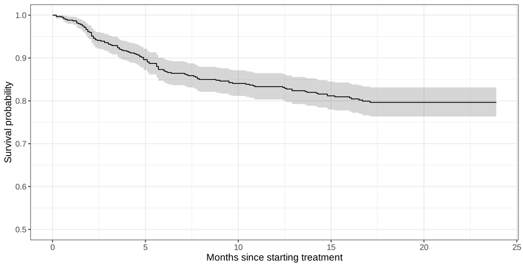

# Topic 2 — Reading the curve

## Survival at a time

```r
summary(km, times = c(6, 12, 18))
```

```
Call: survfit(formula = Surv(time_months, status) ~ 1, data = tb)

 time n.risk n.event survival std.err lower 95% CI upper 95% CI
    6    490      76    0.870  0.0140        0.843        0.897
   12    439      20    0.833  0.0156        0.803        0.864
   18    244      17    0.796  0.0173        0.763        0.831
```

“Survival at 12 months was **83%** (95% CI 80–86%).” Time points beyond the **longest follow-up** (here about 24 months) cannot be estimated.

## The median survival time

- The **median** is the time at which the curve **crosses 0.5**
- Here fewer than half the patients died, so the curve **never reaches 0.5**: the median is **not reached** (`NA`)
- Report **survival at fixed times** (12, 24 months) or the **restricted mean** instead
- Never replace “not reached” with the median of the observed times

```r
summary(km)$table[c("records", "events", "median")]
```

```
records  events  median
    600     113      NA
```

## Confidence and the tail

The curve is **least reliable at the right end**, where **few patients remain at risk**: confidence bands widen and a single death moves the curve a lot. Always show the **number at risk** and avoid over-reading the tail.

# Topic 3 — Curves by group

## HIV-positive and negative

```r
km_grp <- survfit(Surv(time_months, status) ~ hiv, data = tb)
summary(km_grp, times = 12)$surv |> round(2)
```

```
[1] 0.85 0.72
```

```r
ggsurvfit(km_grp) + add_confidence_interval() + add_risktable() + scale_ggsurvfit(x_scales = list(breaks = seq(0, 24, 6))) +
  labs(x = "Months since starting treatment", y = "Survival probability")
```

- Positive patients have **lower survival** throughout
- **Overlapping bands** early on; separation grows
- The **risk table** shows how many remain: only **63** HIV-positive patients started, so the right end is thin

## HIV-positive and negative

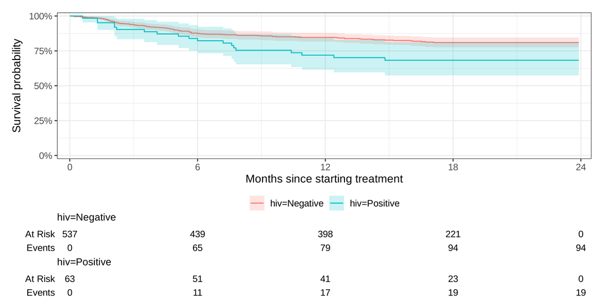

## Reporting a Kaplan-Meier analysis

- **Number of patients and events** per group
- **Median follow-up** (reverse KM)
- **Survival at fixed times** with 95% CI, or the median with CI if reached
- The **figure** with number at risk, a clear axis and the **log-rank p-value** (Session 3)

## 🔧 Switch to R — Lab 2

**File:** `survival-workshop/labs/lab2_km.R`

- `survfit()` · `summary(times = )` · the median
- `ggsurvfit()` with confidence band and risk table
- curves by HIV status

**Time:** 35 minutes · answer the Q questions in the comments

## Self-check quiz (1/5)

In a Kaplan-Meier analysis the median survival time is reported as ‘not reached’. What does this mean?

- The patients were followed for too short a time to be analysed
- The median could not be calculated because of missing data in the file
- Fewer than half of the patients had died by the end of follow-up
- More than half of the patients in the whole cohort were censored

## Self-check quiz (2/5)

What happens to a censored patient in the Kaplan-Meier calculation?

- They are counted as a death at the time of censoring in the data
- They stay at risk until censored, then leave with no drop
- They are removed from the whole analysis from the very start of it
- They are counted as surviving until the end of the study period

## Self-check quiz (3/5)

Why should a Kaplan-Meier plot show the number at risk beneath the curve?

- It gives the p-value for the comparison made between the two groups
- It shows the hazard ratio for each one of the groups in the plot
- The right end of the curve rests on few patients and is unreliable
- It is included only to make the plot look more complete and tidy

## Self-check quiz (4/5)

At 12 months the Kaplan-Meier survival for HIV-positive patients is 0.72. How should this be stated?

- 72% of HIV-positive patients died within 12 months of starting treatment
- The hazard of dying in the HIV-positive group is 0.72 per month of time
- The median survival of HIV-positive patients is about 0.72 of a year
- About 72% of HIV-positive patients are estimated alive at 12 months

## Self-check quiz (5/5)

What is the survival estimate at 30 months if the longest follow-up in the data is 24 months?

- It cannot be estimated from these data
- It is the same as the survival at 24 months
- It is zero, since nobody was followed that long
- It equals the median survival of the cohort

## Score and take-home

**Your score:**

- KM estimates survival with a **step function**; censored patients **leave the risk set**
- Report **survival at fixed times** with CI; the **median** may be ‘not reached’
- Always show the **number at risk**; beware the thin right tail
- KM is **descriptive**: the log-rank test and Cox model compare groups

**Next:** Session 3: comparing curves